# LAB5

Jose Sanchez, Andre Pivaral , Roberto Najera

2026-03-27

## Preparación de datos

```r
library(e1071)
library(caret)
library(dplyr)
library(ggplot2)

# Cargar el RData y obtener el objeto sin importar su nombre
objetos_antes <- ls()
load("listings_limpio.RData")
objetos_nuevo <- setdiff(ls(), c(objetos_antes, "objetos_antes"))
cat("Objeto cargado:", objetos_nuevo, "\n")
```

```
## Objeto cargado: listings
```

```r
# Asignar a df directamente
df <- get(objetos_nuevo[1])

# Ver estructura del dataset
glimpse(df)
```

```
## Rows: 171,748
## Columns: 71
## $ id                                           <dbl> 5456, 6448, 8502, 13035, …
## $ last_scraped                                 <date> 2025-09-17, 2025-09-17, …
## $ source                                       <fct> city scrape, city scrape,…
## $ name                                         <chr> "Walk to 6th, Rainey St a…
## $ description                                  <chr> "Great central  location …
## $ neighborhood_overview                        <chr> "My neighborhood is ideal…
## $ host_id                                      <int> 8028, 14156, 25298, 50793…
## $ host_name                                    <chr> "Sylvia", "Amy", "Karen",…
## $ host_since                                   <date> 2009-02-16, 2009-04-20, …
## $ host_location                                <chr> "Austin, TX", "Austin, TX…
## $ host_about                                   <chr> "I am a licensed Real Est…
## $ host_response_time                           <fct> within a few hours, withi…
## $ host_response_rate                           <dbl> 100, 100, 100, 100, 100, …
```

[output cut: 58 more lines]

```r
# df ya está asignado arriba

# Asegurar que price es numérico (en datasets de Airbnb puede venir como character con "$")
if (is.character(df$price)) {
  df$price <- as.numeric(gsub("[$,]", "", df$price))
}

# Eliminar filas con NA en price
df <- df %>% filter(!is.na(price) & price > 0)

summary(df$price)
```

```
##    Min. 1st Qu.  Median    Mean 3rd Qu.    Max.
##     8.0   120.0   193.0   750.5   326.0 50123.0
```

## 1. Modelo de Regresión con Naive Bayes

Naive Bayes es originalmente un algoritmo de clasificación. Para usarlo como modelo predictivo sobre el precio (variable continua), se discretiza el precio en categorías basadas en cuartiles, permitiendo comparar el desempeño con los modelos anteriores.

```r
# Discretizar price en 4 categorías usando cuartiles
cuartiles <- quantile(df$price, probs = c(0, 0.25, 0.5, 0.75, 1))
cat("Cuartiles del precio:\n")
```

```
## Cuartiles del precio:
```

```r
print(cuartiles)
```

```
##    0%   25%   50%   75%  100%
##     8   120   193   326 50123
```

```r
df$price_cat <- cut(
  df$price,
  breaks = cuartiles,
  labels = c("Bajo", "Medio-bajo", "Medio-alto", "Alto"),
  include.lowest = TRUE
)

cat("\nDistribución de categorías de precio:\n")
```

```
##
## Distribución de categorías de precio:
```

```r
print(table(df$price_cat))
```

```
##
##       Bajo Medio-bajo Medio-alto       Alto
##      19310      18921      18961      19054
```

```r
# Mismo split que los labs anteriores: set.seed(42), 70% entrenamiento / 30% prueba
set.seed(42)
indice <- createDataPartition(df$price_cat, p = 0.70, list = FALSE)

train <- df[indice, ]
test  <- df[-indice, ]

cat("Filas en entrenamiento:", nrow(train), "\n")
```

```
## Filas en entrenamiento: 53373
```

```r
cat("Filas en prueba:", nrow(test), "\n")
```

```
## Filas en prueba: 22873
```

```r
# Seleccionar variables predictoras numéricas y categóricas relevantes
# (ajustar según las columnas disponibles en el dataset)
vars_numericas <- c("accommodates", "bedrooms", "bathrooms", "beds",
                    "number_of_reviews", "review_scores_rating",
                    "minimum_nights", "calculated_host_listings_count")

vars_categoricas <- c("room_type", "neighbourhood_cleansed")

# Filtrar solo las que existen en el dataframe
vars_numericas   <- vars_numericas[vars_numericas %in% names(df)]
vars_categoricas <- vars_categoricas[vars_categoricas %in% names(df)]
vars_modelo      <- c(vars_numericas, vars_categoricas)

cat("Variables usadas en el modelo:\n")
```

```
## Variables usadas en el modelo:
```

```r
print(vars_modelo)
```

```
## [1] "accommodates"                   "bedrooms"
## [3] "bathrooms"                      "beds"
## [5] "number_of_reviews"              "review_scores_rating"
## [7] "minimum_nights"                 "calculated_host_listings_count"
## [9] "room_type"
```

```r
# Subsets limpios (sin NA en variables del modelo)
train_nb <- train %>% select(all_of(c(vars_modelo, "price_cat"))) %>% na.omit()
test_nb  <- test  %>% select(all_of(c(vars_modelo, "price_cat"))) %>% na.omit()
```

```r
# Entrenar modelo Naive Bayes
modelo_nb <- naiveBayes(price_cat ~ ., data = train_nb)
modelo_nb
```

```
##
## Naive Bayes Classifier for Discrete Predictors
##
## Call:
## naiveBayes.default(x = X, y = Y, laplace = laplace)
##
## A-priori probabilities:
## Y
##       Bajo Medio-bajo Medio-alto       Alto
##  0.2683077  0.2628023  0.2491298  0.2197602
##
## Conditional probabilities:
##             accommodates
## Y                [,1]     [,2]
##   Bajo       2.890877 1.672310
##   Medio-bajo 4.193646 1.959812
##   Medio-alto 5.198521 2.422090
##   Alto       7.474431 3.503458
##
##             bedrooms
## Y                [,1]      [,2]
##   Bajo       1.065457 0.7072847
##   Medio-bajo 1.457410 1.0371443
##   Medio-alto 1.903570 1.0752581
##   Alto       2.941615 1.6151354
##
##             bathrooms
## Y                [,1]      [,2]
##   Bajo       1.173054 0.5156169
##   Medio-bajo 1.296096 0.5690145
##   Medio-alto 1.607798 0.7024415
##   Alto       2.442081 1.2342955
##
##             beds
## Y                [,1]      [,2]
##   Bajo       1.579617 0.9791232
##   Medio-bajo 2.218490 1.2165899
##   Medio-alto 2.819651 1.6345251
##   Alto       4.316149 2.8369517
##
```

[output cut: 19 more lines]

```
##   Alto        5.300414 13.13751
##
##             calculated_host_listings_count
## Y                [,1]      [,2]
##   Bajo       17.77472  42.57584
##   Medio-bajo 40.89638  92.78644
##   Medio-alto 54.75756 107.78115
##   Alto       67.20342 126.16808
##
##             room_type
## Y            Entire home/apt   Hotel room Private room  Shared room
##   Bajo          0.6831439715 0.0011022554 0.3054943191 0.0102594540
##   Medio-bajo    0.9394044321 0.0012984765 0.0592105263 0.0000865651
##   Medio-alto    0.9516939092 0.0037439503 0.0443795087 0.0001826317
##   Alto          0.9484472050 0.0083850932 0.0428571429 0.0003105590
```

**Interpretación del modelo:** El modelo Naive Bayes calcula, para cada categoría de precio, la probabilidad a priori y la distribución de cada variable predictora. Se asume independencia condicional entre las variables dado el precio. Las tablas de probabilidades condicionales muestran, por ejemplo, qué valores de `accommodates` o `room_type` son más comunes en listings baratos versus caros.

## 2. Predicción y Análisis de Resultados

```r
# Predecir en el conjunto de prueba
pred_nb <- predict(modelo_nb, newdata = test_nb)

# Tabla de confusión
conf_matrix <- confusionMatrix(pred_nb, test_nb$price_cat)
print(conf_matrix)
```

```
## Confusion Matrix and Statistics
##
##             Reference
## Prediction   Bajo Medio-bajo Medio-alto Alto
##   Bajo       4011       2487       1388  427
##   Medio-bajo  603       1123        878  318
##   Medio-alto  315       1011       1676 1329
##   Alto        116        287        752 2044
##
## Overall Statistics
##
##                Accuracy : 0.4718
##                  95% CI : (0.4647, 0.479)
##     No Information Rate : 0.2689
##     P-Value [Acc > NIR] : < 2.2e-16
##
##                   Kappa : 0.2911
##
##  Mcnemar's Test P-Value : < 2.2e-16
##
## Statistics by Class:
##
##                      Class: Bajo Class: Medio-bajo Class: Medio-alto
## Sensitivity               0.7950           0.22881           0.35705
## Specificity               0.6864           0.87017           0.81131
## Pos Pred Value            0.4825           0.38433           0.38698
## Neg Pred Value            0.9011           0.76109           0.79091
## Prevalence                0.2689           0.26155           0.25015
## Detection Rate            0.2137           0.05985           0.08932
## Detection Prevalence      0.4430           0.15572           0.23080
## Balanced Accuracy         0.7407           0.54949           0.58418
##                      Class: Alto
## Sensitivity               0.4964
## Specificity               0.9211
## Pos Pred Value            0.6389
## Neg Pred Value            0.8668
## Prevalence                0.2195
## Detection Rate            0.1089
## Detection Prevalence      0.1705
## Balanced Accuracy         0.7088
```

### Métricas de desempeño

```r
# Accuracy global
accuracy <- conf_matrix$overall["Accuracy"]
cat("Accuracy:", round(accuracy, 4), "\n\n")
```

```
## Accuracy: 0.4718
```

```r
# Precision, Recall y F1 por clase
metricas_clase <- data.frame(
  Clase     = rownames(conf_matrix$byClass),
  Precision = round(conf_matrix$byClass[, "Precision"], 4),
  Recall    = round(conf_matrix$byClass[, "Recall"],    4),
  F1        = round(conf_matrix$byClass[, "F1"],        4)
)
print(metricas_clase)
```

```
##                               Clase Precision Recall     F1
## Class: Bajo             Class: Bajo    0.4825 0.7950 0.6005
## Class: Medio-bajo Class: Medio-bajo    0.3843 0.2288 0.2868
## Class: Medio-alto Class: Medio-alto    0.3870 0.3571 0.3714
## Class: Alto             Class: Alto    0.6389 0.4964 0.5587
```

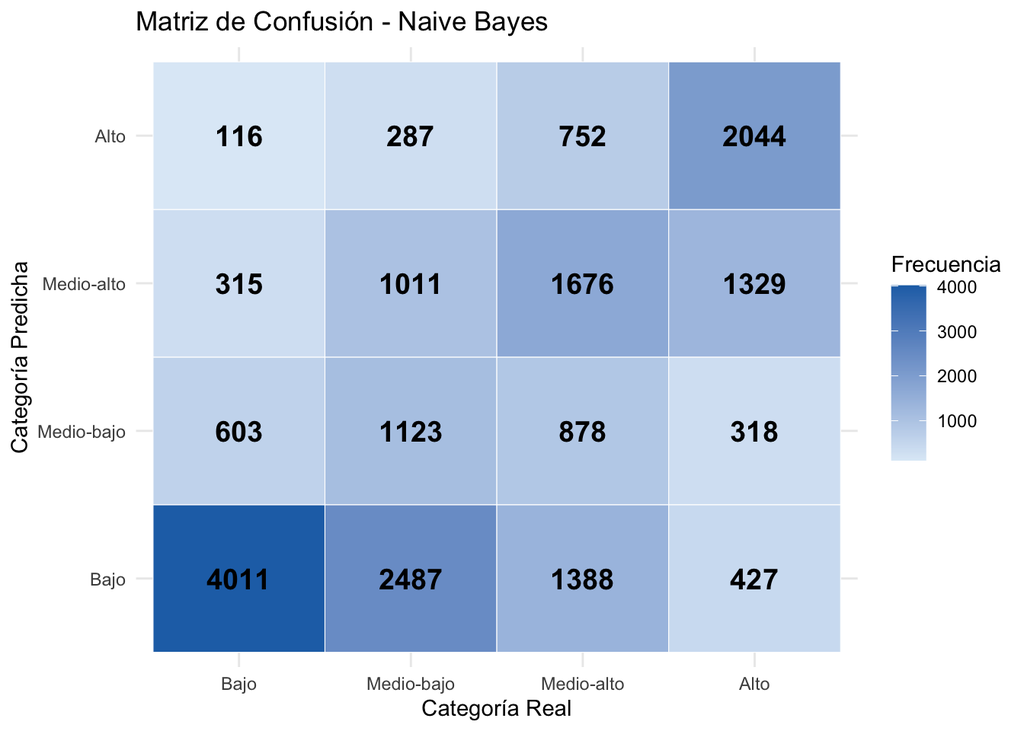

```r
# Visualizar la matriz de confusión
cm_df <- as.data.frame(conf_matrix$table)
colnames(cm_df) <- c("Predicho", "Real", "Frecuencia")

ggplot(cm_df, aes(x = Real, y = Predicho, fill = Frecuencia)) +
  geom_tile(color = "white") +
  geom_text(aes(label = Frecuencia), size = 5, fontface = "bold") +
  scale_fill_gradient(low = "#deebf7", high = "#2171b5") +
  labs(title = "Matriz de Confusión - Naive Bayes",
       x = "Categoría Real", y = "Categoría Predicha") +
  theme_minimal()
```

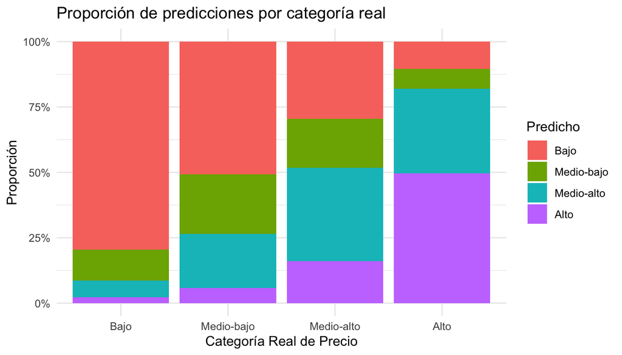

```r
# Distribución de predicciones vs valores reales
comparacion <- data.frame(
  Real     = test_nb$price_cat,
  Predicho = pred_nb
)

ggplot(comparacion, aes(x = Real, fill = Predicho)) +
  geom_bar(position = "fill") +
  scale_y_continuous(labels = scales::percent) +
  labs(title = "Proporción de predicciones por categoría real",
       x = "Categoría Real de Precio",
       y = "Proporción",
       fill = "Predicho") +
  theme_minimal()
```